# University of Trieste - 2020/2021

Statical Methods for Data Science - Homework 2

GROUP J: Cavuoti, SEMI, Sicklinger

Created on November 30, 2020

## Block 2

## Exercises LEC

Refer to the theoretical lecture about bootstrap.

### Exercise 1

Compute the bootstrap-based confidence interval for $\mathtt{score}$ using the studentized method.

**Solution** We consider the $\mathtt{score}$ dataset, as displayed below.

```r
score <- read.table("student_score.txt", header = TRUE)
score
```

```
##    mech vecs alg analy stat
## 1     7   51  43    17   22
## 2    44   69  53    53   53
## 3    49   41  61    49   64
## 4    59   70  68    62   56
## 5    34   42  50    47   29
## 6    46   40  47    29   17
## 7     0   40  21     9   14
## 8    32   45  49    57   64
## 9    49   57  47    39   26
## 10   52   64  60    63   54
## 11   44   61  52    62   46
## 12   36   59  51    45   51
## 13   42   60  54    49   33
## 14    5   30  44    36   18
## 15   22   58  53    56   41
## 16   18   51  40    56   30
## 17   41   63  49    46   34
## 18   48   38  41    44   33
## 19   31   42  48    54   68
## 20   42   69  61    55   45
## 21   46   49  53    59   37
## 22   63   63  65    70   63
```

```r
cor(score)
```

```
##            mech      vecs       alg     analy      stat
## mech  1.0000000 0.4978075 0.7560364 0.6534763 0.5357744
## vecs  0.4978075 1.0000000 0.5922624 0.5071353 0.3786038
## alg   0.7560364 0.5922624 1.0000000 0.7627546 0.6698255
## analy 0.6534763 0.5071353 0.7627546 1.0000000 0.7376712
## stat  0.5357744 0.3786038 0.6698255 0.7376712 1.0000000
```

```r
# define function to calculate eigenratio of cor(score)
psi_fun <- function(data) {
  eig <- eigen(cor(data), symmetric=TRUE, only.values=TRUE)$values
  return(max(eig) / sum(eig))
}
# compute observed eigenratio
psi_obs <- psi_fun(score)
```

In order to compute the *bootstrap-based confidence interval* with the studentized method, we use two procedures: 1. *jackknife* calculation to compute the standard error $SE(\psi*)$, needed at each step of the bootstrap method 2. *double bootstrap*

The first procedure yields:

```r
# number of iterations
B <- 10^4
n <- nrow(score)
pre_fact <- sqrt((n-1)/n)
# vector of statistics from resampling
s_vect <- rep(0, B)
# vector of standard error
SE_jack <- c()
z <- c()
time_jack <- system.time(
  for(i in 1:B) {
    ind <- sample(1:n, n, replace = TRUE)
    score2<- score[ind,]
    s_vect[i] <- psi_fun(score2)
    # jackknife in bootstrap
    psi_j <- c()
    for(j in 1:n) psi_j[j] <- psi_fun(score2[-j,])
    SE_jack[i] <- pre_fact*sqrt(sum((psi_j-mean(psi_j))^2))

    z[i]=(s_vect[i]-psi_obs)/SE_jack[i]
  }
)
SE_boot <- sd(s_vect)
# confidence intervals
studentized_ci_jack <- psi_obs - SE_boot*quantile(z,prob=c(0.95,0.05))
attr(studentized_ci_jack,"names") <- NULL
studentized_ci_jack
```

```
## [1] 0.5481378 0.8223991
```

```r
# time requested to complete the task
time_jack
```

```
##    user  system elapsed
##  35.710   0.004  35.717
```

The second procedure yields instead:

```r
# number of iterations
C <- 10^4; C_loop <- 10^2
# vector of statistics from resampling
s_vect_2 <- rep(0, C)
# vector of standard error
SE_boot_i <- c()
z2 <- c()
time_dboot <- system.time(
  for(i in 1:C) {
    ind <- sample(1:n, n, replace = TRUE)
    score2<- score[ind,]
    s_vect_2[i] <- psi_fun(score2)
    # double bootstrap
    s_vect_loop <- rep(0, C_loop)
    for (j in 1:C_loop) {
      ind2 <- sample(1:n, n, replace = TRUE)
      score3 <- score2[ind2,]
      s_vect_loop[j] <- psi_fun(score3)
    }
    SE_boot_i[i] <- sd(s_vect_loop)

    z2[i]=(s_vect_2[i]-psi_obs)/SE_boot_i[i]
  }
)
SE_boot <- sd(s_vect_2)
# confidence intervals
studentized_ci_doubleboot <- psi_obs - SE_boot*quantile(z2,prob=c(0.95,0.05), na.rm = T)
attr(studentized_ci_doubleboot,"names") <- NULL
studentized_ci_doubleboot
```

```
## [1] 0.5469859 0.8465938
```

```r
# time requested to complete the task
time_dboot
```

```
##    user  system elapsed
## 167.904   0.000 167.920
```

We can observe that the second procedure gives wider intervals but processing takes longer compared with the first one.

### Exercise 2

Compute bootstrap-based confidence intervals for the $\mathtt{score}$ dataset using the $\mathtt{boot}$ package.

**Solution**

We consider the previous dataset calculating the *confidence intervals* using the $\mathtt{boot}$ package. To run it, the re-definition of `psi_fun` function is required.

```r
psi_fun_boot <- function(data,indices) {
   d <- data[indices,]
   eig <- eigen(cor(d), symmetric=TRUE, only.values=TRUE)$values
   psi = max(eig)/sum(eig)
}
library(boot)
```

We compute the *confidence intervals* with the following code:

```r
result_nostud <- boot(score, statistic=psi_fun_boot, R=10^4)
boot.ci(result_nostud,type="all")
```

```
## BOOTSTRAP CONFIDENCE INTERVAL CALCULATIONS
## Based on 10000 bootstrap replicates
##
## CALL :
## boot.ci(boot.out = result_nostud, type = "all")
##
## Intervals :
## Level      Normal              Basic
## 95%   ( 0.5487,  0.8470 )   ( 0.5694,  0.8727 )
##
## Level     Percentile            BCa
## 95%   ( 0.5123,  0.8157 )   ( 0.5192,  0.8186 )
## Calculations and Intervals on Original Scale
```

We notice that the *studentized method* was not performed. To compute also studentized confidence intervals we add a function which allow to compute the requested variances. Then, we define the function needed to generate all the requested types of confidence intervals.

```r
library(magrittr)
library(purrr)
psi_fun_stud <- function(data,indices,its) {
  d <- data[indices,]
  eig <- eigen(cor(d), symmetric=TRUE, only.values=TRUE)$values
  v <- boot(d, statistic=psi_fun_boot, R=its)%>%pluck("t")%>%var(na.rm = TRUE)
  c(max(eig)/sum(eig),v)
}
```

At the end, confidence intervals are given by the following code:

```r
result <- boot(score, statistic=psi_fun_stud, its=100, R=1000)
boot.ci(result,type="all")
```

```
## BOOTSTRAP CONFIDENCE INTERVAL CALCULATIONS
## Based on 1000 bootstrap replicates
##
## CALL :
## boot.ci(boot.out = result, type = "all")
##
## Intervals :
## Level      Normal              Basic             Studentized
## 95%   ( 0.5449,  0.8516 )   ( 0.5607,  0.8953 )   ( 0.4728,  0.9482 )
##
## Level     Percentile            BCa
## 95%   ( 0.4898,  0.8244 )   ( 0.4906,  0.8245 )
## Calculations and Intervals on Original Scale
```

## Exercises LAB

### Exercise 1

Compute the MLE and the observed information matrix for a gamma model with parameters shape $\alpha$ and scale $\beta$.

**Solution**

The probability distribution function for a gamma model with parameters $\alpha$ and $\beta$ is
$$f(y;\alpha,\beta)=\frac{\beta^{\alpha}}{\Gamma(\alpha)}y^{\alpha-1}e^{-\beta y}$$
Then, the likelihood function is given by
$$L(\alpha,\beta;y)=\prod_{i=1}^{n}f(\alpha,\beta;y_i)=\prod_{i=1}^{n}\frac{\beta^{\alpha}}{\Gamma(\alpha)}y_i^{\alpha-1}e^{-\beta y_i}$$
from which one can compute the log-likelihood function as
$$l(\alpha,\beta;y)=\log L(\alpha,\beta;y)=\alpha(n\log \beta) +(\alpha-1) \sum_{i=1}^n\log y_i-n\log\Gamma(\alpha)-\beta\sum_{i=1}^ny_i$$
This can be computed using the following code.

```r
log_like_gamma <- function(data,parameter){
  sum(dgamma(data, shape = parameter[1], rate = parameter[2], log = TRUE))
}
```

The previous quantity can be studied in a qualitative way by making contour plots.

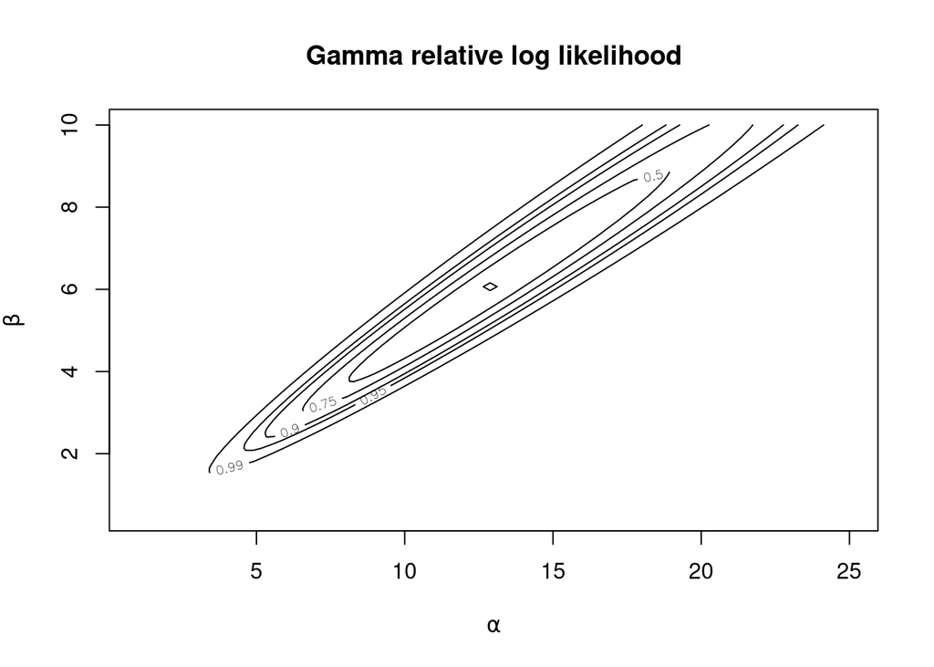

```r
# create data
n <- 15
y <- rgamma(15, shape = 9, rate = 4)
# create grid for parameters
alpha <- seq(1, 25, length = 100)
beta <- seq(0.5, 10, length = 100)
parameter_values <- expand.grid(alpha, beta)
log_like_values <- apply(parameter_values, 1, log_like_gamma, data = y)
log_like_values <- matrix(log_like_values, nrow = length(alpha), ncol = length(beta), byrow = F)
confidence_levels <- c(0,0.5,0.75,0.9,0.95,0.99)
# create contour plot
contour(alpha, beta, log_like_values-max(log_like_values),
        levels = -qchisq(confidence_levels,2)/2, xlab = expression(alpha),
        labels = as.character(confidence_levels), ylab = expression(beta))
title('Gamma relative log likelihood')
```

First derivative of the log-likelihood function yields:
$$\frac{\partial l}{\partial \alpha}=n\log\beta+\sum_{i=1}^n\log x_i-n\psi(\alpha)$$
where
$$\psi(\alpha)=\frac{\partial}{\partial \alpha}\log\Gamma(\alpha)=\frac{1}{\Gamma(\alpha)}\frac{\partial\Gamma(\alpha)}{\partial\alpha}$$
and
$$\frac{\partial l}{\partial \beta}=\frac{n\alpha}{\beta}-\sum_{i=1}^ny_i.$$
Setting the latter equal to zero, one obtains
$$\beta_{\alpha}=\frac{n\alpha}{\sum_{i=1}^n}$$
which, substituted in derivative with respect to $\alpha$ of the log-likelihood and putting it equal to zero, yields
$$n\log\left(\frac{n\alpha}{\sum_{i=1}^n}\right)-n\psi(\alpha)+\sum_{i=1}^n\log y_i=0$$
The last equation can be solved numerically to evaluate the *MLE estimates* with the following code.

```r
# computing MLE
alpha_hat <- uniroot(function(x) n*log(n*x/sum(y))-n*digamma(x)+sum(log(y)), c(1e-15,25))$root
#alpha_hat
lambda_hat <- n*alpha_hat/sum(y)
#lambda_hat
c(alpha_hat, lambda_hat)
```

```
## [1] 12.725292  5.966237
```

In order to retrieve the *observed information matrix*, we employ the second derivative as follow:
$$\frac{\partial^2 l}{\partial \alpha^2}=-n\frac{\partial}{\partial\alpha}\psi(\alpha)$$
$$\frac{\partial l}{\partial\alpha\partial\beta}=\frac{n}{\beta}$$
$$\frac{\partial^2 l}{\partial\beta^2}=-\frac{n\alpha}{\beta^2}$$
Using this result in $\mathtt{R}$ code:

```r
# computing observed information matrix
j_matrix <- matrix(NA, nrow = 2, ncol = 2)
j_matrix[1,1] <- n*trigamma(alpha_hat)
j_matrix[1,2] <- j_matrix[2,1] <- -n/lambda_hat
j_matrix[2,2] <- n*alpha_hat/(lambda_hat^2)
solve(j_matrix)
```

```
##           [,1]     [,2]
## [1,] 21.040602 9.864859
## [2,]  9.864859 4.811611
```

Finally, the standard error are given by:

```r
MLE_SE <- sqrt(diag(solve(j_matrix)))
MLE_SE
```

```
## [1] 4.587004 2.193538
```

## Exercise 2

The *Wald confidence interval* with level $1-\alpha$ is defined as:

$$\hat{\gamma} \pm z_{1-\alpha/2}j_{P}(\hat{\gamma})^{-1/2}.$$
Compute the Wald confidence interval of level 0.95, plot the results, and evaluate via simulation the empirical coverage of the confidence interval.

**Solution**

```r
# define log likelihood function
log_lik_weibull <- function( data, param){
  -sum(dweibull(data, shape = param[1], scale = param[2], log = TRUE))
}

empirical_coverage <- c()
for(j in 1:10){
    M <- 10000; mat.ci <- matrix(NA, nrow = M, ncol = 2)
  for(i in 1:M){
    # generating data for simulation
    y_sim <- rweibull(15, shape = 7, scale = 155)
    # estimating for i-th simulation
    weib.y.mle_sim <- optim(c(1,1), fn=log_lik_weibull, hessian=T, method='L-BFGS-B',
                      lower=rep(1,2), upper=rep(Inf,2), data=y_sim)
    # extracting hessian
    h <- weib.y.mle_sim$hessian
    # estimation of standard error
    mle.se_sim <- sqrt(diag(solve(h)))
    # computation of i-th confidence interval
    mat.ci[i,] <- weib.y.mle_sim$par[1] + qnorm(0.975)*mle.se_sim[1]*c(-1,1)
  }
  # empirical coverage of the confidence interval
  empirical_coverage[j] <- mean(mat.ci[,1] < 7 & mat.ci[,2] > 7, na.rm = T)
}
empirical_coverage
```

```
##  [1] 0.9507 0.9540 0.9525 0.9489 0.9511 0.9491 0.9542 0.9477 0.9510 0.9505
```

The result above shows that the probability to find the exact value of the parameter inside the computed confidence interval can be well approximated by a *standard normal distribution*.

## Exercise 3

Repeat the steps above write the profile log-likelihood, plot it and find the deviance confidence intervals— considering this time $\gamma$ as a nuisance parameter and $\beta$ as the parameter of interest.

**Solution**

The profile log likelihood for $\beta$ is:
$$l_{P}(\beta) = \underset{\gamma}{\max}\ l(\gamma, \beta; y)$$
However, in this case, we don’t have a closed form for the *MLE estimate* of $\beta$ given $\gamma$ and therefore we must resort to numerical optimization: for each value of $\beta$ we compute the *MLE estimate* for the parameter $\gamma$.

```r
n <- 15
y <- rweibull(n, shape = 7, scale = 155)
```

```r
log_lik_weibul <- function(data, gamma, beta){
  -sum(dweibull(data, shape = gamma, scale = beta, log = TRUE))
}

beta <- seq(110, 200, length.out = 100)
profile_lik <- vector(length=100)

for (i in 1:100) {
  profile_lik[i] <- nlm(log_lik_weibul, c(5), data=y, beta=beta[i])$minimum
}
```

The plot of the *profile log-likelihood* is given by:

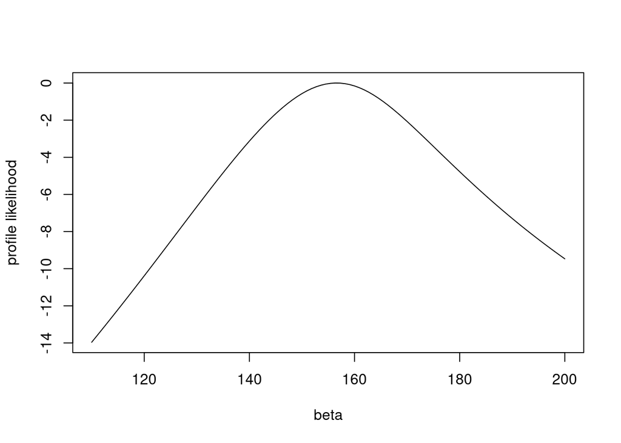

```r
plot(beta, -profile_lik-max(-profile_lik), type="l", ylab="profile likelihood")
```

We plot now the *confidence intervals*.

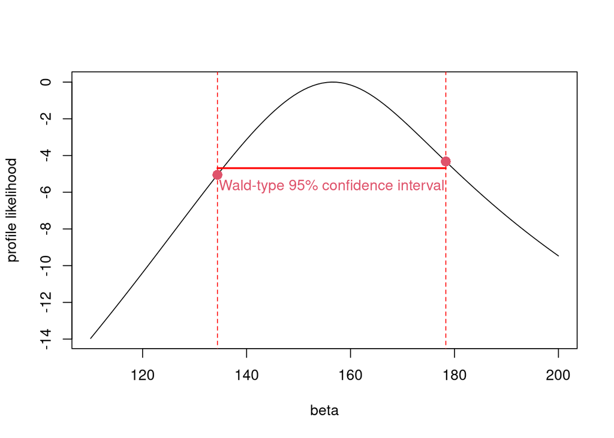

```r
conf.level <- 0.95

# confidence interval
for (i in 1:100) {
  if ( profile_lik[i] == min(profile_lik)) i_max <- i
}
beta_hat <- beta[i_max]
gamma_hat <- uniroot(function(x) n/x + sum(log(y)) -n*log(beta_hat) - n*sum((y/beta_hat)^x*log(y/beta_hat)), c(1,15))$root

hess <- optimHess(c(gamma_hat,beta_hat),log_lik_weibull,data=y)
J_obs_to_minus1 <- solve(hess)
se_wald_95 <- sqrt(J_obs_to_minus1[2,2])

wald_95 <- beta_hat + c(-1,1)*qnorm(0.975)*se_wald_95

y_text_1 <- -nlm(log_lik_weibul, c(5), data=y, beta=wald_95[1])$minimum-max(-profile_lik)
y_text_2 <- -nlm(log_lik_weibul, c(5), data=y, beta=wald_95[2])$minimum-max(-profile_lik)

plot(beta, -profile_lik-max(-profile_lik), type="l", ylab="profile likelihood")
segments( wald_95[1], (y_text_1+y_text_2)/2, wald_95[2], (y_text_1+y_text_2)/2, col="red", lty =1, lwd=2  )
text(beta_hat,(y_text_1+y_text_2)/2-1,"Wald-type 95% confidence interval",col=2)

segments( wald_95[1],1, wald_95[1],
          -30, col="red", lty=2)
segments( wald_95[2],1, wald_95[2],
          -30, col="red", lty=2)

points(wald_95[1], y_text_1, pch=16, col=2, cex=1.5)
points(wald_95[2], y_text_2, pch=16, col=2, cex=1.5)
```

Finally, we compute the *empirical coverage* of the $95\%$ *Wald-type* confidence interval:

```r
M <- 10000; mat.ci <- matrix(NA, nrow = M, ncol = 2)
for(i in 1:M){
  # generating data for simulation
  y_sim <- rweibull(15, shape = 7, scale = 155)
  # estimating for i-th simulation
  weib.y.mle_sim <- optim(c(1,1), fn=log_lik_weibull, hessian=T, method='L-BFGS-B',
                      lower=rep(1,2), upper=rep(Inf,2), data=y_sim)
  # extracting hessian
  h <- weib.y.mle_sim$hessian
  # estimation of standard error
  mle.se_sim <- sqrt(diag(solve(h)))
  # computation of i-th confidence interval
  mat.ci[i,] <- weib.y.mle_sim$par[2] + qnorm(0.975)*mle.se_sim[2]*c(-1,1)
}
# empirical coverage of confidence interval
mean(mat.ci[,1] < 155 & mat.ci[,2] > 155, na.rm = T)
```

```
## [1] 0.9146
```

```r
#input values
#true mean
theta_sample <- 2
#likelihood variance
sigma2 <- 2
#sample size
n <- 10
#prior mean
mu <- 7
#prior variance
tau2 <- 2

#generate some data
set.seed(123)
y <- rnorm(n,theta_sample, sqrt(sigma2))

#posterior mean
mu_star <- ((1/tau2)*mu+(n/sigma2)*mean(y))/( (1/tau2)+(n/sigma2))
#posterior standard deviation
sd_star <- sqrt(1/( (1/tau2)+(n/sigma2)))

library(rstan)
#launch Stan model
data<- list(N=n, y=y, sigma =sqrt(sigma2), mu = mu, tau = sqrt(tau2))
fit <- stan(file="normal.stan", data = data, chains = 4, iter=2000)
#extract Stan output
sim <- extract(fit)
```

## Exercise 4

In $\mathsf{sim}$ in the code above, you find the MCMC output which allows to approximate the posterior distribution of our parameter of interest with $S$ draws of $\theta$. Plot the empirical cumulative distribution function and compare it with the theoretical cumulative distribution function of the posterior distribution.

**Solution**

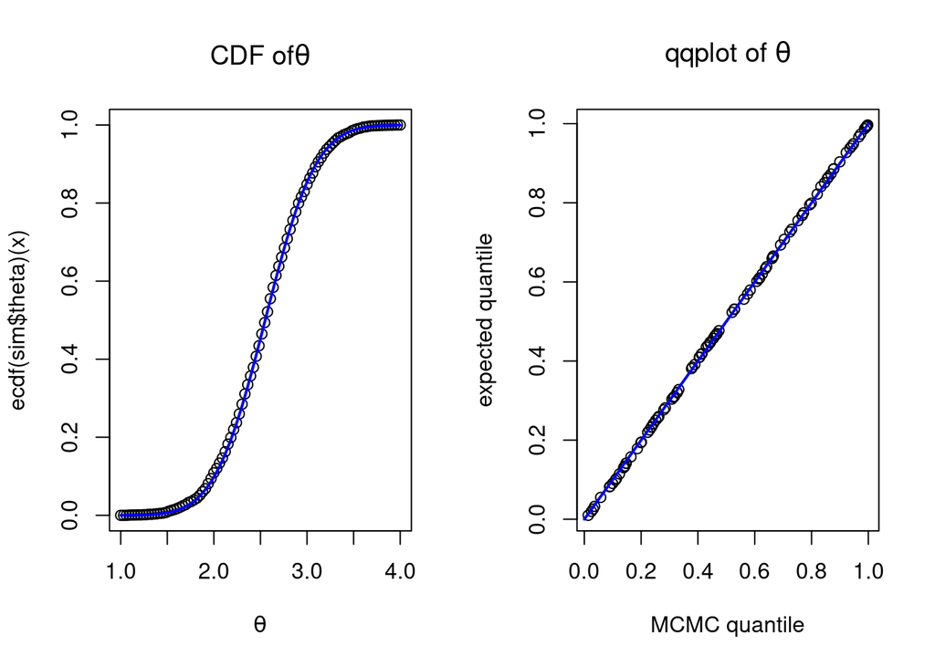

```r
library(MASS)
par(mfrow=c(1,2))
x <- seq(1,4,length.out=100)
# Plot of the cdf of the posterior distribution of theta simulated by MCMC
plot(x, ecdf(sim$theta)(x), xlab=expression(theta), main=expression(paste("CDF of",theta)))
# true analytical posterior
curve(pnorm(x, mu_star, sd_star), col="blue", lwd=2, add=T)


# qqplot of the MCMC quantile and analytical quantile
x <- rnorm(100, mu_star, sd_star)
qqplot(ecdf(sim$theta)(x), pnorm(x, mu_star, sd_star), main=expression(paste("qqplot of ", theta)),
       xlab="MCMC quantile", ylab="expected quantile")
v = seq(0, 1, length.out = 100)
lines(v,v, col="blue", lwd=2, )
```

From both the plot of the empirical cdf and the qqplot we see that the *random draws* provided by MCMC simulation are distributed in the same way as the draws from the true analytical posterior distribution.

## Exercise 5

Launch the following line of $\mathsf{R}$ code:

```r
posterior <- as.array(fit, )
```

Use now the $\mathsf{bayesplot}$ package. Read the help and produce for this example, using the object `posterior`, the following plots:

- posterior intervals.
- posterior areas.
- marginal posterior distributions for the parameters.

Quickly comment.

**Solution**

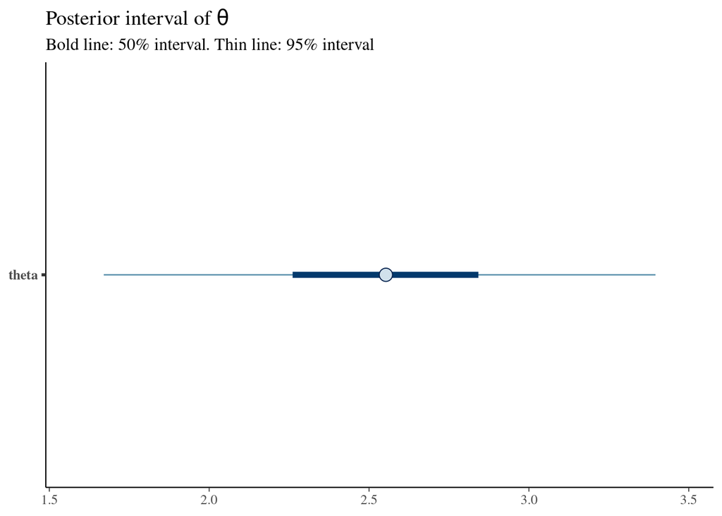

```r
library(bayesplot)
posterior <- as.array(fit)

# Posterior intervals of the parameter theta
mcmc_intervals(posterior, pars = "theta", prob_outer = 0.95) +
  ggplot2::labs(
   title = expression(paste("Posterior interval of ", theta)),
   subtitle = "Bold line: 50% interval. Thin line: 95% interval"
 )
```

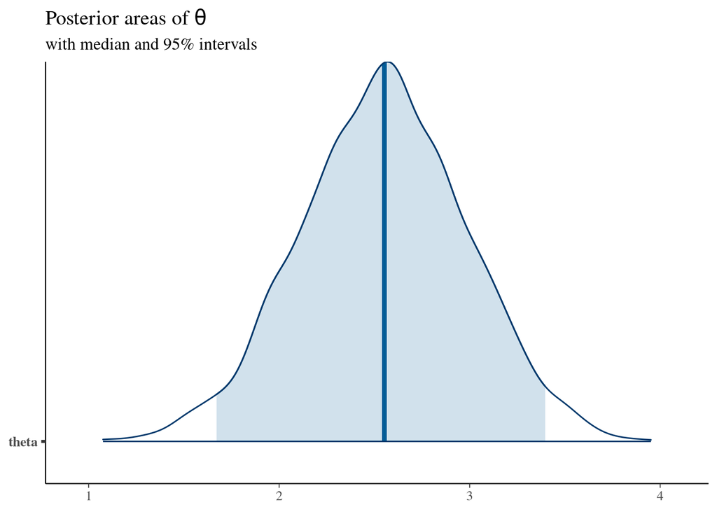

```r
# Posterior areas of the parameter theta
mcmc_areas(posterior, pars = "theta", prob=0.95) +
  ggplot2::labs(
   title = expression(paste("Posterior areas of ", theta)),
   subtitle = "with median and 95% intervals"
 )
```

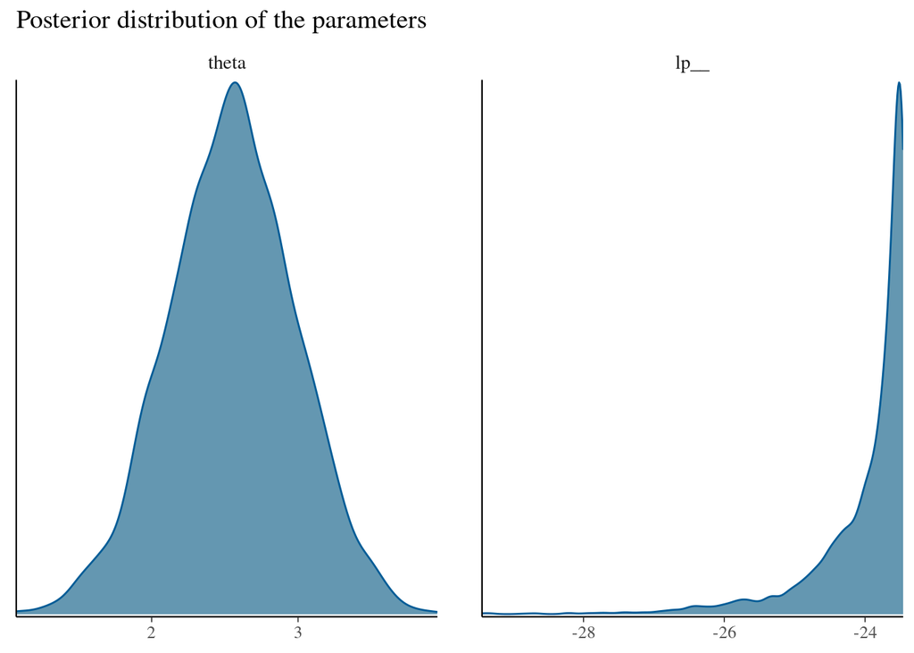

```r
# Posterior distribution of both the parameter theta and lp__
mcmc_dens(posterior) +
  ggplot2::labs(
   title = "Posterior distribution of the parameters"
 )
```

## Exercise 6

Suppose you receive $n = 15$ phone calls in a day, and you want to build a model to assess their average length. Your likelihood for each call length is $y_i \sim \mathsf{Poisson}(\lambda)$. Now, you have to choose the prior $\pi(\lambda)$. Please, tell which of these priors is adequate to describe the problem, and provide a short motivation for each of them:

1. $\pi(\lambda)= \mathsf{Beta}(4,2)$;
2. $\pi(\lambda)= \mathsf{Normal}(1,2)$;
3. $\pi(\lambda)=\mathsf{Gamma}(4,2)$;

Now, compute your posterior as $\pi(\lambda|y)\propto L(\lambda;y)\pi(\lambda)$ for the selected prior. If your first choice was correct, you will be able to compute it analitically.

**Solution**

1. The *beta distribution* is defined in the interval $[0,1]$; so we are assuming that our phone calls will not last longer than 1 minute. However our *likelihood* is a *Poisson distribution* which has support in $[0,+\infty]$ and therefore we could have some observations that will fall out of bounds of the prior distribution. This evidence leads us to *discard the beta prior distribution*.
2. The *normal distribution* is defined in the interval ($-\infty$,$+\infty$) which means that our phone calls can have negative length (no sense, to be discarded). To make it useful, we have to consider a *truncated normal distribution* which is equal to $0$ in $[-\infty,0]$).
3. The *gamma distribution* has the same support of our likelihood function $[0,+\infty]$, this leads us to consider this distribution as the prior distribution. In our case $\mathsf{Gamma}(4,2)$ has mean $2$ and standard deviation $1$: so we are assuming that the average length of our phone calls will be near $2$. Another property of the gamma distribution is that it is the conjugate prior for the Poisson likelihood function, as can be seen with some simple algebra:

$$L(\lambda;\boldsymbol{y})\pi(\lambda) =
\prod_{i=1}^n\bigg[\mathsf{Pois}(\lambda; y_i)\bigg]\mathsf{Gamma}(\lambda;\alpha, \beta) \propto
e^{-n\lambda}\lambda^{\sum_{i=1}^{n} y_i} \lambda^{\alpha-1}e^{-\beta\lambda} =
\lambda^{\alpha + \sum_{i=1}^{n} y_i} e^{-(\beta+n)\lambda}$$

The last expression represents a $\mathsf{Gamma}(\sum_{i=1}^{n} y_i + \alpha, \beta+n)$ distribution, the mean of the distribution takes the form:
$$\hat \lambda = \frac{\sum_{i=1}^{n} y_i + \alpha}{\beta + n} =
\frac{\sum_{i=1}^{n} y_i}{\beta+n} + \frac{\alpha}{\beta+n} =
\frac{n}{\beta+n}\frac{\sum_{i=1}^{n} y_i}{n} + \frac{\beta}{\beta+n} \frac{\alpha}{\beta}$$

From the last expression we can clearly see that *the greater the number of observations, the more the posterior mean tends to the sample mean*, as expected.

## Exercise 7

Go to this link: [rstan](https://github.com/stan-dev/rstan/wiki/RStan-Getting-Started), and follow the instructions to download and install the $\mathsf{rstan}$ library. Once you did it successfully, open the file model called $\mathsf{biparametric.stan}$, and replace the line:

$$\mathsf{ target+=cauchy\_lpdf(sigma| 0, 2.5);}$$

with the following one:

$$\mathsf{ target+=uniform\_lpdf(sigma| 0.1, 10);}$$

Which prior are you now assuming for your parameter $\sigma$? Reproduce the same plots as above and briefly comment.

**Solution**

I am assuming for the parameter $\sigma$ a uniform prior distribution between $0.1$ and $10$,

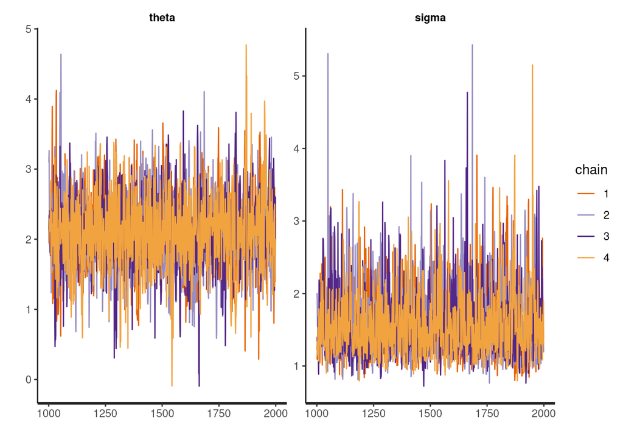

```r
#launch biparametric Stan model

data3 <- list(N=n, y=y, a=-10, b=10)
fit3 <- stan(file="biparametric.stan", data = data3, chains = 4, iter=2000,
  refresh=-1)

#extract stan output for biparametric model

sim3 <- extract(fit3)
posterior_biv <- as.matrix(fit3)

theta_est <- mean(sim3$theta)
sigma_est <- mean(sim3$sigma)
c(theta_est, sigma_est)
traceplot(fit3, pars=c("theta", "sigma"))
```

[output not shown]

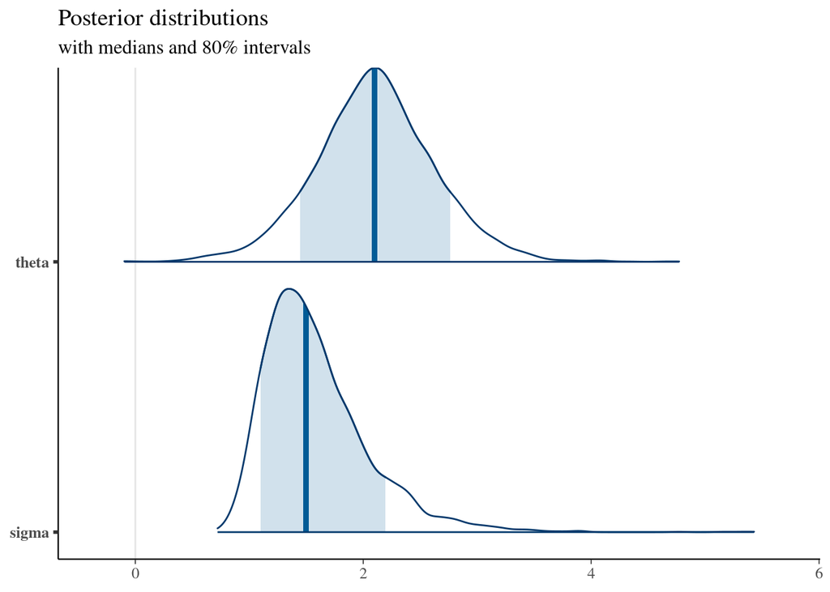

```r
plot_title <- ggtitle("Posterior distributions",
                      "with medians and 80% intervals")

mcmc_areas(posterior_biv,
           pars = c("theta","sigma"),
           prob = 0.8) + plot_title
```

Since we are assuming a uniform prior distribution for $\sigma$ all the values between $0.1$ and $10$ are *equally possible*, this leads to fatter tails of both the $\sigma$ and $\theta$ distribution. The fact that the distribution of $\theta$ changes is pretty interesting and is hinting us that the parameters $\sigma$ and $\theta$ aren’t really independent: in fact, if high values of $\sigma$ are less penalized we are more likely to have a wider distribution. We could choose $\theta$ to be farther from the sample mean, which in turn leads to a heavier tailed distribution for $\theta$. Another difference which arise using an *uniform distribution* instead of the Cauchy distribution is that we are bounding the sigma parameter between $0.1$ and $10$. However, values greater than $10$ or less than $0.1$ are very unlikely from the beginning, and therefore, in the practice, this constraint does not impact.

## Exercise 8

Simulate a sample of size $n=14$ from a Bernoulli distribution parameter $p=0.5$.

- Looking at the $\mathsf{Stan}$ code for the other models, write a short $\mathsf{Stan}$ Beta-Binomial model, where $p$ has a $\mathsf{Beta}(a,b)$ prior with $a=3$, $b=3$.
- extract the posterior distribution with the function $\mathsf{extract()}$;
- produce some plots with the $\mathsf{bayesplot}$ package and comment.
- compute analitically the posterior distribution and compare it with the $\mathsf{Stan}$ distribution.

**Solution**

The *stan file* for this simulation is:

```
 data{
  int<lower=0> N;
  int y[N];
  real a;
  real b;
 }
 parameters{
  real p;
 }
 model{
  target += bernoulli_lpmf(y | p);
  target += beta_lpdf(p | a, b);
 }
```

We didn’t set the parameters in the stan file because we will provide them through R.

Now we run the MCMC simulation

```r
## Simulates with Rstan the above model

## Input values
# true probability
p <- 0.5
# parameters of the prior distribution
a <- 3
b <- 3
# sample size
n <- 14
# generate some data
y <- rbinom(n, 1, p)

# Launch Stan model
library(rstan)
data <- list(N=n, y=y, a=a, b=b)
fit <- stan(file="beta-binomial.stan", data=data, chains=4, iter=2000)
```

extract Stan output

```r
sim <- extract(fit)
```

and produce *posterior intervals*, *areas* and *distribution plots* using the $\mathsf{bayesplot}$ package

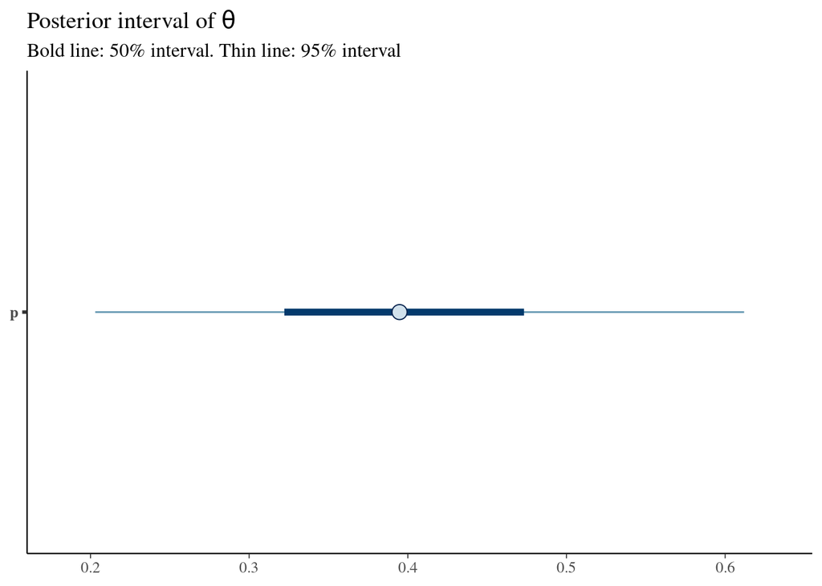

```r
library(bayesplot)
posterior <- as.array(fit)

# Posterior intervals of the parameter theta
mcmc_intervals(posterior, pars = "p", prob_outer = 0.95) +
  ggplot2::labs(
   title = expression(paste("Posterior interval of ", theta)),
   subtitle = "Bold line: 50% interval. Thin line: 95% interval"
 )
```

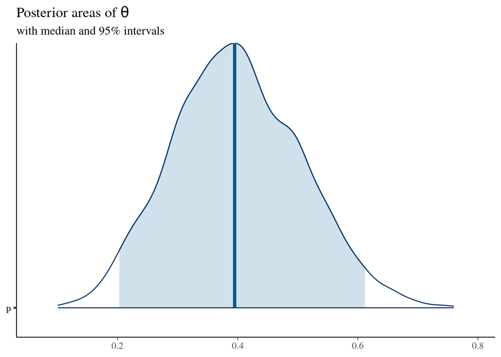

```r
# Posterior areas of the parameter theta
mcmc_areas(posterior, pars = "p", prob=0.95) +
  ggplot2::labs(
   title = expression(paste("Posterior areas of ", theta)),
   subtitle = "with median and 95% intervals"
 )
```

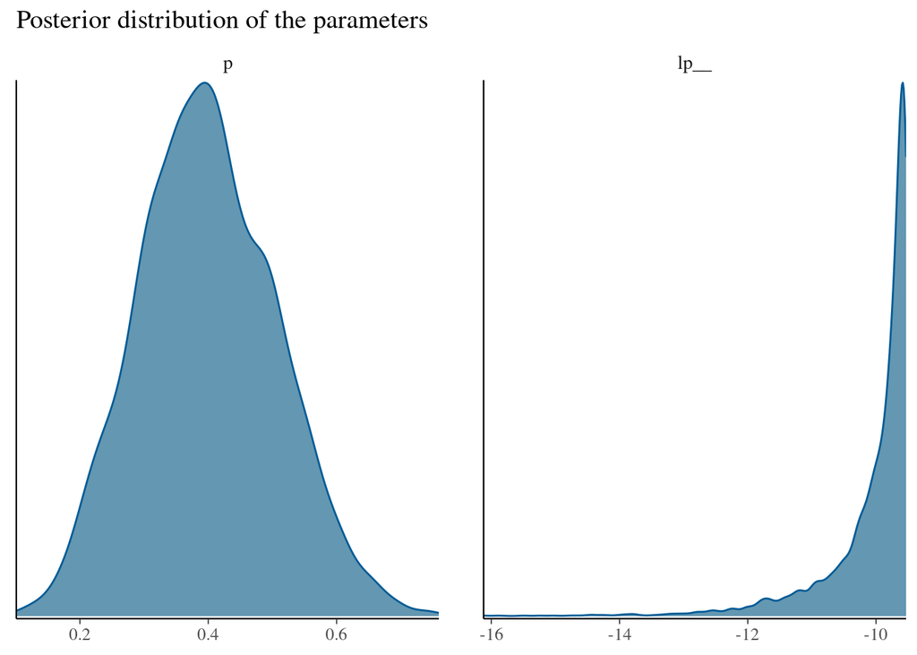

```r
# Posterior distribution of both the parameter theta and lp__
mcmc_dens(posterior) +
  ggplot2::labs(
   title = "Posterior distribution of the parameters"
 )
```

We observe that the *posterior distribution of the parameter* is very wide, both due to the small amount of observation that we have and because $\mathsf{Beta}(3,3)$ prior is quite flat near $0.5$ (as shown in the graph below)

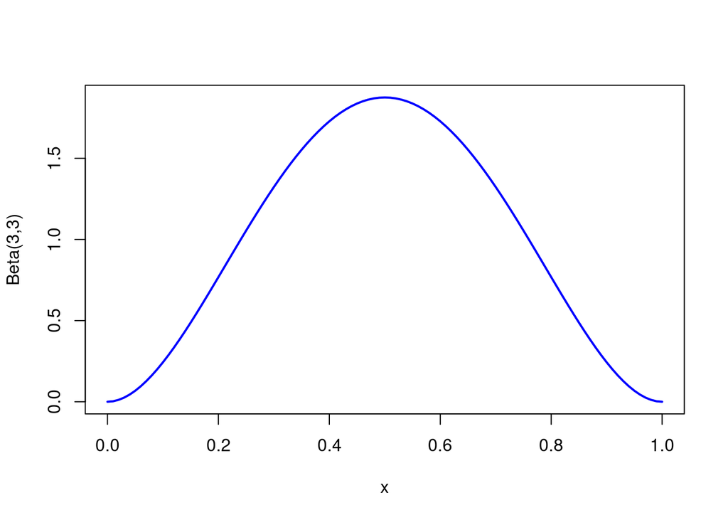

```r
curve(dbeta(x, 3,3), col="blue", lwd=2, ylab = "Beta(3,3)")
```

We now compare the MCMC posterior draws with the analytical posterior distribution

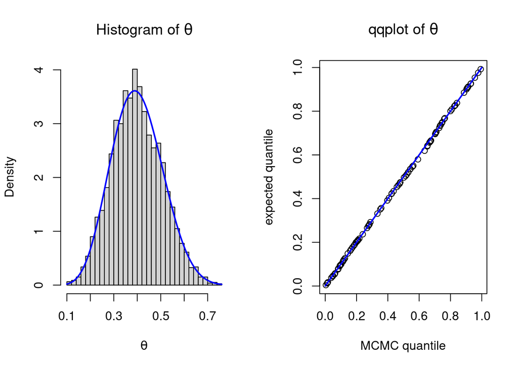

```r
a_post <- a + sum(y)
b_post <- b + n - sum(y)

library(MASS)
par(mfrow=c(1,2))
# histogram of the posterior distribution of theta simulated by MCMC
hist.scott(sim$p, prob=TRUE, xlab = expression(theta), main=expression(paste("Histogram of ", theta)))
# true analytical posterior
curve(dbeta(x, a_post, b_post), col="blue", lwd=2, add=T)


# qqplot of the MCMC quantile and analytical quantile
x <- rbeta(100, a_post, b_post)
qqplot(ecdf(sim$p)(x), pbeta(x, a_post, b_post), main=expression(paste("qqplot of ", theta)),
       xlab="MCMC quantile", ylab="expected quantile")
v = seq(0, 1, length.out = 100)
lines(v,v, col="blue", lwd=2, )
```

From both the histogram and the qqplot above we see that the random draws provided by MCMC simulation are distributed in the same way as the draws from the true analytical distribution.